# Topic 2-05: fgsea

Zuguang Gu z.gu@dkfz.de

2025-05-23

The permutation-based method is by nature very slow, especially if you want to get p-values in high precision. In this document, we demonstrate the use of a extremely efficient package **fgsea**, but only for the gene-permutation-based method.

We still use the p53 dataset.

```r
lt = readRDS(system.file("extdata", "p53_expr.rds", package = "GSEAtutorial"))
expr = lt$expr
condition = lt$condition

ln = strsplit(readLines(system.file("extdata", "c2.symbols.gmt", package = "GSEAtutorial")), "\t")
gs = lapply(ln, function(x) x[-(1:2)])
names(gs) = sapply(ln, function(x) x[1])

library(matrixStats)
m1 = expr[, condition == "WT"]  # only samples in group 1
m2 = expr[, condition == "MUT"]  # only samples in group 2
s = (rowMeans(m1) - rowMeans(m2))/(rowSds(m1) + rowSds(m2)) # gene-level difference scores
s = sort(s, decreasing = TRUE)
```

The use of **fgsea** is striaghtforward, with the `fgsea()` function:

```r
library(fgsea)
df = fgsea(gs, s)
head(df)
```

```
##                            pathway       pval      padj    log2err         ES
##                             <char>      <num>     <num>      <num>      <num>
## 1:                     41bbPathway 0.60962567 0.8478866 0.08407456 -0.2709496
## 2: ADULT_LIVER_vs_FETAL_LIVER_GNF2 0.44354839 0.7541767 0.06508776  0.2593511
## 3:     ANDROGEN_GENES_FROM_NETAFFX 0.51881720 0.8060196 0.05760911  0.2476218
## 4:               ANDROGEN_UP_GENES 0.07214231 0.3760588 0.28780513 -0.2987018
## 5:                  ANTI_CD44_DOWN 0.82776350 0.9372940 0.06628422 -0.2597386
## 6:                    ANTI_CD44_UP 0.57750760 0.8450566 0.05834528  0.2848141
##           NES  size  leadingEdge
##         <num> <int>       <list>
## 1: -0.8946790    18 RELA, MA....
## 2:  1.0182782    61 RODH-4, ....
## 3:  0.9568062    53 RODH-4, ....
## 4: -1.3260339    57 VAPA, LM....
## 5: -0.7321391    12 LAMP2, E....
## 6:  0.9140728    23 IL1A, AL....
```

You only need to make gene IDs in `s` (as the name of the vector) are the same as in `gs`.

## Implement helper functions

The same as the `ora_*()` functions for different types of gene sets, we can also implement the `fgsea_*()` functions.

We first define a wrapper function where we can rename the colnames of the data frame from `fgsea()`, just let it be consistent to the results from `ora_*()` functions. We also reorder the result data frame by p-values.

```r
fgsea_wrapper = function(s, gs, min_size = 5, max_size = 1000, ...) {
    s = sort(s, decreasing = TRUE)
    df = fgsea(gs, s, minSize = min_size, maxSize = max_size, ...)
    df = as.data.frame(df)
    colnames(df) = c("gene_set", "p_value", "p_adjust", "log2_p_err", "es", "nes", "n_gs", "leading_edge")
    df = df[order(df$p_value), , drop = FALSE]
    rownames(df) = NULL
    df
}
```

Now we can write these helper functions. The `load_*_genesets()` functions are already defined in the previous document.

```r
fgsea_go = function(s, org_db = org.Hs.eg.db::org.Hs.eg.db, ontology = "BP", ...) {
    lt = load_go_genesets(org_db, ontology)

    df = fgsea_wrapper(s, lt$gs, ...)
    df$description = lt$names[df$gene_set]
    df
}

# db: pathway, module, ko, network, disease, drug
fgsea_kegg = function(s, organism = "hsa", db = "pathway", ...) {
    lt = load_kegg_genesets(organism, db)

    df = fgsea_wrapper(s, lt$gs, ...)
    df$description = lt$names[df$gene_set]
    df
}

fgsea_msigdb = function(s, collection = "h.all", version = "2024.1.Hs", ...) {
    lt = load_msigdb_genesets(collection, version)

    df = fgsea_wrapper(s, lt$gs, ...)
    df
}

fgsea_reactome = function(s, organism = "HSA", ...) {
    lt = load_reactome_genesets(organism)

    df = fgsea_wrapper(s, lt$gs, ...)
    df$description = lt$names[df$gene_set]
    df
}

fgsea_keywords = function(s, organism = "human", ...) {
    gs = load_keyword_genesets(organism)

    df = fgsea_wrapper(s, gs, ...)
    df
}

# the human phenotype ontology
fgsea_phenotype = function(s, organism = "human", ...) {
    lt = load_simona_genesets(ontology_hp, "hp", organism = organism)

    df = fgsea_wrapper(s, lt$gs, ...)
    df$description = lt$names[df$gene_set]
    df
}

# disease ontology
fgsea_disease = function(s, organism = "human", ...) {
    lt = load_simona_genesets(ontology_rdo, "rdo", organism = organism)

    df = fgsea_wrapper(s, lt$gs, ...)
    df$description = lt$names[df$gene_set]
    df
}
```

Keep in mind, all these `fgsea_*()` functions use EntreZ IDs as the internal IDs. Then for the input gene score vector, genes should also have EntreZ IDs.

Use the helper function first to generate a global mapping between symbols and EntreZ IDs:

```r
library(org.Hs.eg.db)
map = map_to_entrez_id("SYMBOL", org.Hs.eg.db)
```

`map_to_entrez_id()` only returns mapping for protein-coding genes. According to the pratice we have made, the human, the mapping between symbols and EntreZ IDs is one-to-one. But we need to be careful. 1. gene symbols change from time to time. You cannot ensure the symbol used in the dataset is the most recent version. 2. for other organisms, we don’t know whether the mapping is also one-to-one. Let’s do it in a conservative way.

```r
symbol = names(s)
entrez = map[symbol]
```

in `entrez`, there are possible `NA` values or duplicated values. We first remove `NA`s:

```r
s2 = unname(s)
s2 = s2[!is.na(entrez)]
entrez = entrez[!is.na(entrez)]
```

Then remove duplicates, either only keep the first one, or take the mean.

```r
tapply(s2, entrez, function(x) x[1])
tapply(s2, entrez, function(x) mean(x))
```

In this exmaple, I would only take the first one

```r
s2 = tapply(s2, entrez, function(x) x[1])
```

This is how it is implemented in `convert_to_entrez_id()`.

```r
s2 = convert_to_entrez_id(s)
```

```
##   gene id might be SYMBOL (p =  0.590 )
```

And let’s try these `fgsea_*()` helper functions:

```r
head(fgsea_go(s2))
```

```
##     gene_set      p_value     p_adjust log2_p_err         es       nes n_gs
## 1 GO:0007186 6.792575e-11 4.974882e-07  0.8390889  0.3600615  1.849328  512
## 2 GO:0002682 1.457033e-08 5.335656e-05  0.7477397  0.2997243  1.577816  912
## 3 GO:0022402 5.373524e-07 1.311856e-03  0.6594444 -0.2522013 -1.568094  577
## 4 GO:0002684 3.111896e-06 5.412779e-03  0.6272567  0.2981775  1.547563  645
## 5 GO:1902850 3.695234e-06 5.412779e-03  0.6272567 -0.4574162 -2.105057   71
## 6 GO:0006811 5.169939e-06 5.945012e-03  0.6105269  0.2888781  1.502334  667
##   leading_edge                                               description
## 1 23620, 2....              G protein-coupled receptor signaling pathway
## 2 1026, 58....                       regulation of immune system process
## 3 29899, 1....                                        cell cycle process
## 4 1026, 58....              positive regulation of immune system process
## 5 29899, 9.... microtubule cytoskeleton organization involved in mitosis
## 6 581, 891....                                  monoatomic ion transport
```

```r
head(fgsea_kegg(s2))
```

```
##   gene_set      p_value     p_adjust log2_p_err        es      nes n_gs
## 1 hsa04080 2.129224e-08 7.516160e-06  0.7337620 0.4052099 1.942341  234
## 2 hsa03010 1.076822e-07 1.900592e-05  0.7049757 0.5122149 2.156409   85
## 3 hsa04060 1.453630e-06 1.710437e-04  0.6435518 0.3936669 1.851562  193
## 4 hsa04081 1.448011e-05 1.277869e-03  0.5933255 0.3766489 1.757811  180
## 5 hsa04940 3.240015e-05 2.287450e-03  0.5573322 0.5971851 2.115662   36
## 6 hsa05332 7.107893e-05 4.181810e-03  0.5384341 0.6071862 2.039809   29
##   leading_edge                                                    description
## 1 23620, 2.... Neuroactive ligand-receptor interaction - Homo sapiens (human)
## 2 6223, 61....                                Ribosome - Homo sapiens (human)
## 3 355, 343....  Cytokine-cytokine receptor interaction - Homo sapiens (human)
## 4 2100, 15....                       Hormone signaling - Homo sapiens (human)
## 5 355, 355....                Type I diabetes mellitus - Homo sapiens (human)
## 6 355, 355....               Graft-versus-host disease - Homo sapiens (human)
```

```r
head(fgsea_msigdb(s2))
```

```
##                       gene_set      p_value     p_adjust log2_p_err         es
## 1      HALLMARK_G2M_CHECKPOINT 9.213803e-09 4.606902e-07  0.7477397 -0.4116411
## 2         HALLMARK_E2F_TARGETS 2.463202e-05 4.354882e-04  0.5756103 -0.3555237
## 3 HALLMARK_ALLOGRAFT_REJECTION 2.612929e-05 4.354882e-04  0.5756103  0.3856414
## 4      HALLMARK_UV_RESPONSE_DN 6.901308e-05 7.323723e-04  0.5384341 -0.3538389
## 5     HALLMARK_MITOTIC_SPINDLE 7.323723e-05 7.323723e-04  0.5384341 -0.3662740
## 6   HALLMARK_PROTEIN_SECRETION 1.190969e-03 9.924745e-03  0.4550599 -0.3610550
##         nes n_gs leading_edge
## 1 -2.130557  141 7290, 18....
## 2 -1.842138  129 5810, 11....
## 3  1.812282  168 355, 677....
## 4 -1.798703  122 5195, 21....
## 5 -1.850054  116 9371, 83....
## 6 -1.711399   80 3998, 93....
```

```r
head(fgsea_reactome(s2))
```

```
##        gene_set      p_value     p_adjust log2_p_err         es       nes n_gs
## 1 R-HSA-1640170 2.783988e-10 5.072426e-07  0.8140358 -0.3242206 -1.907576  347
## 2  R-HSA-373076 3.478880e-09 2.515326e-06  0.7749390  0.4380965  2.058566  197
## 3   R-HSA-69278 4.141590e-09 2.515326e-06  0.7614608 -0.3425451 -1.919785  275
## 4  R-HSA-500792 1.117597e-08 5.090653e-06  0.7477397  0.3983994  1.934335  267
## 5  R-HSA-388396 1.125108e-07 4.099895e-05  0.7049757  0.3443831  1.731339  402
## 6   R-HSA-68886 1.637676e-07 4.973077e-05  0.6901325 -0.3743773 -2.023876  171
##   leading_edge                                        description
## 1 9631, 58....                           Homo sapiens: Cell Cycle
## 2 23620, 1.... Homo sapiens: Class A/1 (Rhodopsin-like receptors)
## 3 9631, 55....                  Homo sapiens: Cell Cycle, Mitotic
## 4 23620, 1....                  Homo sapiens: GPCR ligand binding
## 5 23620, 5....           Homo sapiens: GPCR downstream signalling
## 6 9631, 55....                              Homo sapiens: M Phase
```

```r
head(fgsea_keywords(s2))
```

```
##                     gene_set      p_value     p_adjust log2_p_err        es
## 1 G-protein coupled receptor 6.176731e-07 0.0001485504  0.6594444 0.4229840
## 2                 Transducer 6.176731e-07 0.0001485504  0.6594444 0.4229840
## 3      Immunoglobulin domain 1.181733e-06 0.0001894712  0.6435518 0.3915393
## 4                   Receptor 3.124246e-06 0.0003756906  0.6272567 0.3724067
## 5                   Cytokine 2.197934e-05 0.0021144124  0.5756103 0.4520167
## 6          Ribosomal protein 4.348375e-05 0.0034859472  0.5573322 0.4455696
##        nes n_gs leading_edge
## 1 1.965959  175 23620, 1....
## 2 1.965959  175 23620, 1....
## 3 1.841943  209 3140, 94....
## 4 1.771666  222 23620, 1....
## 5 1.925236  100 9518, 35....
## 6 1.874373   91 6223, 61....
```

```r
head(fgsea_phenotype(s2))
```

```
##     gene_set      p_value     p_adjust log2_p_err        es      nes n_gs
## 1 HP:0100733 4.725570e-10 2.388676e-06  0.8012156 0.3816193 1.913616  352
## 2 HP:0006780 1.040511e-09 2.388676e-06  0.7881868 0.3851328 1.919667  341
## 3 HP:0011766 1.250179e-09 2.388676e-06  0.7881868 0.3794016 1.906723  356
## 4 HP:0000828 1.549890e-08 2.220992e-05  0.7337620 0.3591694 1.814263  395
## 5 HP:0100723 7.189114e-08 8.241600e-05  0.7049757 0.3580895 1.799724  367
## 6 HP:0100568 9.601119e-08 9.172269e-05  0.7049757 0.3373351 1.716685  450
##   leading_edge                          description
## 1 1026, 78....    Neoplasm of the parathyroid gland
## 2 1026, 78....                Parathyroid carcinoma
## 3 1026, 78....      Abnormal parathyroid morphology
## 4 1026, 78.... Abnormality of the parathyroid gland
## 5 7832, 31....        Gastrointestinal stroma tumor
## 6 1026, 41....     Neoplasm of the endocrine system
```

```r
head(fgsea_disease(s2))
```

```
##       gene_set      p_value     p_adjust log2_p_err         es       nes n_gs
## 1 DOID:0060230 8.369061e-10 2.434181e-06  0.8012156 -0.4565944 -2.336090  128
## 2    DOID:1540 2.100847e-09 2.434181e-06  0.7749390  0.3893031  1.942574  336
## 3 DOID:9007696 2.100847e-09 2.434181e-06  0.7749390  0.3893031  1.942574  336
## 4 DOID:9004331 2.991362e-09 2.599494e-06  0.7749390  0.3836323  1.914510  341
## 5 DOID:0050629 4.753938e-09 3.304938e-06  0.7614608 -0.4637513 -2.336482  110
## 6 DOID:0060799 7.585523e-08 3.766754e-05  0.7049757 -0.3348616 -1.895574  246
##   leading_edge                                          description
## 1 1072, 10....                          basal ganglia calcification
## 2 7832, 31....                                parathyroid carcinoma
## 3 7832, 31....                                   Parathyroid Cancer
## 4 7832, 31....                                Parathyroid Neoplasms
## 5 1072, 10....                           Aicardi-Goutieres syndrome
## 6 6102, 65.... syndromic X-linked intellectual disability Lubs type
```

## Compare to the native implementations

Let’s have a quick comparison between the `fgsea()` function and gene-permutation-based function we have implemented in the previous document. Under the default setting, both functions perform two-sided test:

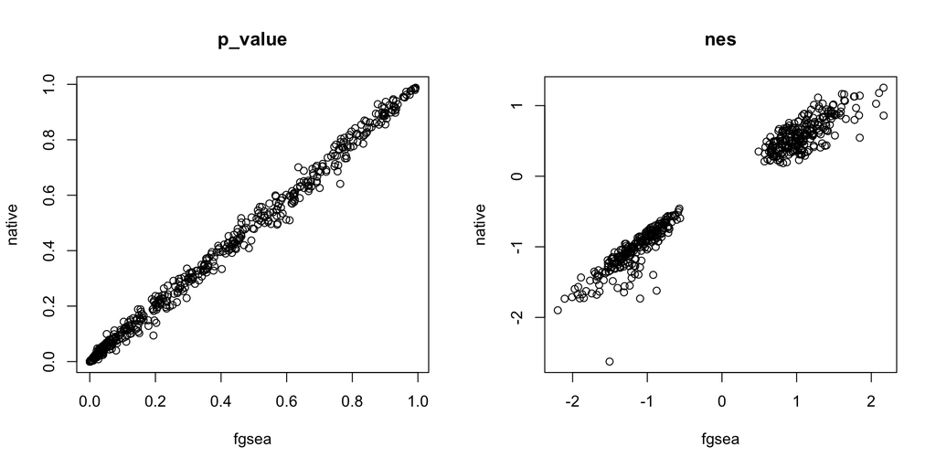

```r
df1 = fgsea_wrapper(s, gs)
df2 = gsea_gene_perm(s, gs, verbose = FALSE)

rownames(df1) = df1$gene_set
rownames(df2) = df2$gene_set

cn = intersect(rownames(df1), rownames(df2))
par(mfrow = c(1, 2))
plot(df1[cn, "p_value"], df2[cn, "p_value"], main = "p_value", xlab = "fgsea", ylab = "native")
plot(df1[cn, "nes"], df2[cn, "nes"], main = "nes", xlab = "fgsea", ylab = "native")
```

And the one-sided test:

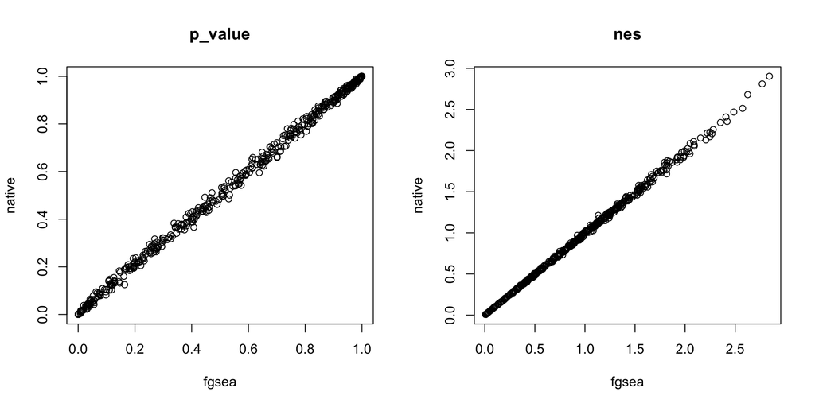

```r
df1 = fgsea_wrapper(s, gs, scoreType = "pos")
df2 = gsea_gene_perm(s, gs, direction = "pos", verbose = FALSE)

rownames(df1) = df1$gene_set
rownames(df2) = df2$gene_set

cn = intersect(rownames(df1), rownames(df2))
par(mfrow = c(1, 2))
plot(df1[cn, "p_value"], df2[cn, "p_value"], main = "p_value", xlab = "fgsea", ylab = "native")
plot(df1[cn, "nes"], df2[cn, "nes"], main = "nes", xlab = "fgsea", ylab = "native")
```

## Other options to capture bi-directional changes

The default behavior of two-sided `fgsea()` or the GSEA method is to capture the stronger one of the up- and down-regulation of genes in a gene set. There are

1. if you want to keep enrichment for both up-regulated and down-regulated genes. You can perform two GSEA analysis, a one-sided test only for up-regulated genes and a second one-sided test only for down-regulated genes.

```r
df1 = fgsea_*(s, gs, scoreType = "pos")
df2 = fgsea_*(s, gs, scoreType = "neg")
```

2. if the gene score is log2fc-like, i.e. with both positive and negative values, if you do not care the direction of the differential expression, you can use `|s|` as the gene scores.

```r
fgsea_*(abs(s), gs, scoreType = "pos")
```